# 2021 Player data eda

J. Heffaran

2026-10-07

```r
library(tidyr)
```

```r
library(ggplot2)
library(tidyverse)
```

We are going to also have a quick look at the player data from 2020-21 season. First, let us read in our df.

```r
df <- read.csv(
"C:/Users/jonty/OneDrive/Documents/GitHub/Group-sprint-0-Sports-Prediction/data/premier_league_player_data_2020_21_to_2024_25/premier_league_2020-21_player_data.csv")
```

Now let us have a look at the headers, and column names.

```r
print(head(df))
```

```
##   Season_End_Year   Squad           Comp                    Player Nation   Pos
## 1            2021 Arsenal Premier League      Rúnar Alex Rúnarsson    ISL    GK
## 2            2021 Arsenal Premier League Pierre-Emerick Aubameyang    GAB    FW
## 3            2021 Arsenal Premier League           Héctor Bellerín    ESP DF,MF
## 4            2021 Arsenal Premier League             Dani Ceballos    ESP    MF
## 5            2021 Arsenal Premier League            Calum Chambers    ENG    DF
## 6            2021 Arsenal Premier League        Gabriel Dos Santos    BRA    DF
##   Age Born MP_Playing Starts_Playing Min_Playing Mins_Per_90_Playing Gls Ast
## 1  25 1995          1              0          16                 0.2   0   0
## 2  31 1989         29             26        2332                25.9  10   3
## 3  25 1995         25             24        2089                23.2   1   2
## 4  23 1996         25             17        1615                17.9   0   3
## 5  25 1995         10              8         753                 8.4   0   2
## 6  22 1997         23             22        1996                22.2   2   0
##   G.A G_minus_PK PK PKatt CrdY CrdR PrgC_Progression PrgP_Progression
```

[output cut: 34 more lines]

```r
#print(names(df))
```

I have provided a cribsheet with explanation of the column names below, note this arduous work was generated by a LLM, and is only for reference.

1. Player / season information

| Column | Meaning |
| --- | --- |
| `Season_End_Year` | The year the season ended. E.g. `2025` means the 2024–25 season. |
| `Squad` | The player’s team. |
| `Comp` | The competition. |
| `Player` | Player’s name. |
| `Nation` | Player’s nationality. |
| `Pos` | Player’s position. |
| `Age` | Player’s age during the season. |
| `Born` | Player’s birth year. |

2. Playing time

| Column | Meaning |
| --- | --- |
| `MP_Playing` | Matches played. |
| `Starts_Playing` | Matches started. |
| `Min_Playing` | Total minutes played. |
| `Mins_Per_90_Playing` | Minutes played expressed as 90-minute games. |

3. Goals and assists

| Column | Meaning |
| --- | --- |
| `Gls` | Goals scored. |
| `Ast` | Assists. |
| `G+A` | Goals + assists. |
| `G_minus_PK` | Goals excluding penalties. |
| `PK` | Penalties scored. |
| `PKatt` | Penalties attempted. |

4. Discipline

| Column | Meaning |
| --- | --- |
| `CrdY` | Yellow cards. |
| `CrdR` | Red cards. |

5. Ball progression

| Column | Meaning |
| --- | --- |
| `PrgC_Progression` | Progressive carries: carrying the ball forwards significantly. |
| `PrgP_Progression` | Progressive passes: passes that significantly advance the ball. |
| `PrgR_Progression` | Progressive passes received: receiving the ball in positions that significantly advance play. |

6. Per-90 statistics

| Column | Meaning |
| --- | --- |
| `Gls_Per` | Goals per 90 minutes. |
| `Ast_Per` | Assists per 90 minutes. |
| `G+A_Per` | Goals + assists per 90 minutes. |
| `G_minus_PK_Per` | Non-penalty goals per 90 minutes. |
| `G+A_minus_PK_Per` | Non-penalty goals + assists per 90 minutes. |

7. Expected goals (xG) and expected assists (xAG)

| Column | Meaning |
| --- | --- |
| `xG_Expected` | Expected goals. |
| `npxG_Expected` | Expected goals excluding penalties. |
| `xAG_Expected` | Expected assists. |
| `npxG+xAG_Expected` | Non-penalty expected goals + expected assists. |

8. Expected statistics per 90

| Column | Meaning |
| --- | --- |
| `xG_Per` | Expected goals per 90 minutes. |
| `xAG_Per` | Expected assists per 90 minutes. |
| `xG+xAG_Per` | Expected goals + expected assists per 90 minutes. |
| `npxG_Per` | Non-penalty expected goals per 90 minutes. |
| `npxG+xAG_Per` | Non-penalty expected goals + expected assists per 90 minutes. |

Now we will explore a quick summary of the data:

```r
summary(df)
```

```
##  Season_End_Year    Squad               Comp              Player
##  Min.   :2021    Length:532         Length:532         Length:532
##  1st Qu.:2021    Class :character   Class :character   Class :character
##  Median :2021    Mode  :character   Mode  :character   Mode  :character
##  Mean   :2021
##  3rd Qu.:2021
##  Max.   :2021
##     Nation              Pos                 Age            Born
##  Length:532         Length:532         Min.   :16.0   Min.   :1981
##  Class :character   Class :character   1st Qu.:22.0   1st Qu.:1991
##  Mode  :character   Mode  :character   Median :26.0   Median :1994
##                                        Mean   :25.5   Mean   :1994
##                                        3rd Qu.:29.0   3rd Qu.:1997
##                                        Max.   :38.0   Max.   :2004
##    MP_Playing    Starts_Playing   Min_Playing   Mins_Per_90_Playing
##  Min.   : 1.00   Min.   : 0.00   Min.   :   1   Min.   : 0.00
##  1st Qu.: 9.00   1st Qu.: 4.00   1st Qu.: 426   1st Qu.: 4.70
##  Median :21.00   Median :15.00   Median :1345   Median :14.95
##  Mean   :19.54   Mean   :15.71   Mean   :1411   Mean   :15.68
##  3rd Qu.:30.00   3rd Qu.:27.00   3rd Qu.:2304   3rd Qu.:25.55
##  Max.   :38.00   Max.   :38.00   Max.   :3420   Max.   :38.00
##       Gls              Ast              G.A           G_minus_PK
##  Min.   : 0.000   Min.   : 0.000   Min.   : 0.000   Min.   : 0.000
##  1st Qu.: 0.000   1st Qu.: 0.000   1st Qu.: 0.000   1st Qu.: 0.000
##  Median : 1.000   Median : 0.000   Median : 1.000   Median : 0.000
##  Mean   : 1.853   Mean   : 1.288   Mean   : 3.141   Mean   : 1.662
##  3rd Qu.: 2.000   3rd Qu.: 2.000   3rd Qu.: 4.000   3rd Qu.: 2.000
##  Max.   :23.000   Max.   :14.000   Max.   :37.000   Max.   :19.000
##        PK             PKatt             CrdY             CrdR
##  Min.   :0.0000   Min.   : 0.000   Min.   : 0.000   Min.   :0.00000
##  1st Qu.:0.0000   1st Qu.: 0.000   1st Qu.: 0.000   1st Qu.:0.00000
##  Median :0.0000   Median : 0.000   Median : 2.000   Median :0.00000
##  Mean   :0.1917   Mean   : 0.235   Mean   : 2.115   Mean   :0.09023
##  3rd Qu.:0.0000   3rd Qu.: 0.000   3rd Qu.: 3.000   3rd Qu.:0.00000
##  Max.   :9.0000   Max.   :10.000   Max.   :12.000   Max.   :2.00000
##  PrgC_Progression PrgP_Progression PrgR_Progression    Gls_Per
##  Min.   :  0.00   Min.   :  0.00   Min.   :  0.00   Min.   :0.00000
##  1st Qu.:  2.00   1st Qu.:  6.00   1st Qu.:  2.00   1st Qu.:0.00000
##  Median : 13.00   Median : 37.00   Median : 21.00   Median :0.03000
##  Mean   : 25.69   Mean   : 53.44   Mean   : 52.93   Mean   :0.09808
```

[output cut: 15 more lines]

```
##  Max.   :20.100   Max.   :16.900   Max.   :11.400   Max.   :24.000
##      xG_Per          xAG_Per          xG.xAG_Per        npxG_Per
##  Min.   :0.0000   Min.   :0.00000   Min.   :0.0000   Min.   :0.0000
##  1st Qu.:0.0100   1st Qu.:0.01000   1st Qu.:0.0400   1st Qu.:0.0100
##  Median :0.0600   Median :0.04500   Median :0.1200   Median :0.0500
##  Mean   :0.1121   Mean   :0.07132   Mean   :0.1835   Mean   :0.1039
##  3rd Qu.:0.1500   3rd Qu.:0.11000   3rd Qu.:0.2800   3rd Qu.:0.1425
##  Max.   :0.8400   Max.   :0.51000   Max.   :0.8400   Max.   :0.8400
##   npxG.xAG_Per        Url
##  Min.   :0.0000   Length:532
##  1st Qu.:0.0400   Class :character
##  Median :0.1100   Mode  :character
##  Mean   :0.1753
##  3rd Qu.:0.2625
##  Max.   :0.8400
```

Note: in previous analysis, we added the birth year and age for four players.

I’m interested in goals scored since trying to model the number of goals in a game could be a method we use to model the result of matchs.

The goals data seems to be skewed. We will plot a histogram of the data to see if this is the case.

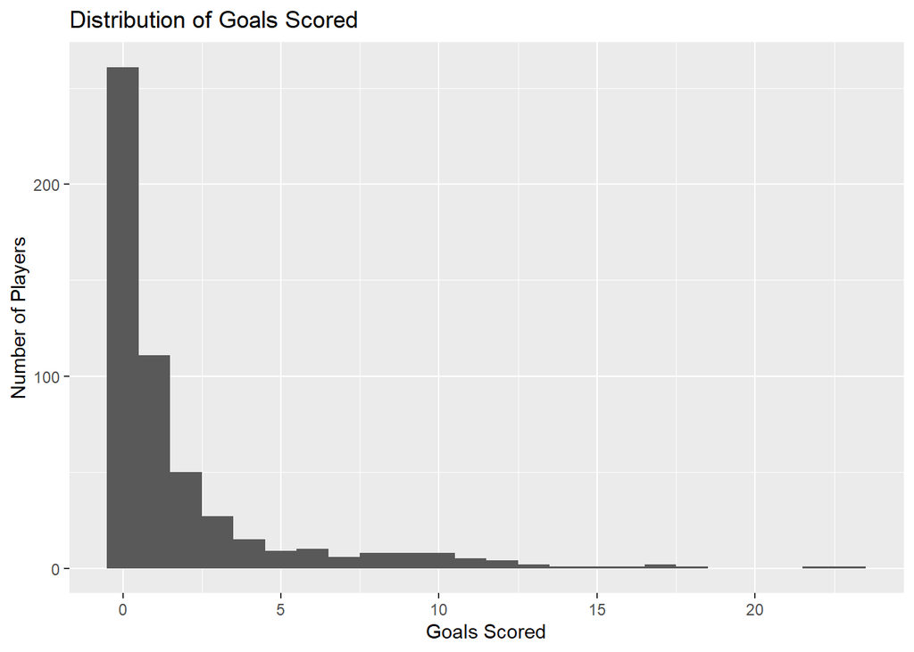

```r
library(ggplot2)
ggplot(df, aes(x = Gls)) +
geom_histogram(binwidth = 1) + labs(
title = "Distribution of Goals Scored",
x = "Goals Scored",
y = "Number of Players"
)
```

We see that many players in our dataset never score, and a few score a lot of goals. Lets now use some classic football measures: a 10 goal a season player is a term used to describe a usually quite average, if not reliable striker. We will use bin sizes now to have a look at the number of such players.

[figure not shown]

```r
df %>%mutate(
    Goals_Bin = cut(
      Gls,
      breaks = c(-1, 0, 7, 12, 19, Inf),
      labels = c("0", "1–7", "8–12", "13–19", "20+" )
    )
  ) %>%
  ggplot(aes(x = Goals_Bin)) +
  geom_bar() +
  geom_text(
    stat = "count",
    aes(label = after_stat(count)),
    vjust = -0.5
  ) +
  geom_bar() +
  labs(
    title = "Distribution of Goals Scored in 24-25",
    x = "Goals",
    y = "Number of Players"
  ) +
  theme_minimal()
```

We see there a quite a few 10 goal a season players. There are also few exceptionally high scoring players, only two players scoring 20+ goals this season.

Let us see how the number of goals scored is distributed by position. We would expect the more attacking the position, the more goals are scored.

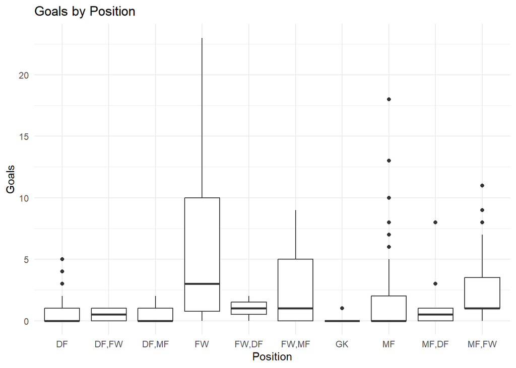

```r
ggplot(df, aes(x = Pos, y = Gls)) +
  geom_boxplot() +
  labs(
    title = "Goals by Position",
    x = "Position",
    y = "Goals"
  ) +
  theme_minimal()
```

Here we see that Forwards (FW) definitely have the greatest mean amount of goals scored. Note that some players play in multiple positions. A particularly weird combination is forwards whom also play in defense. I expect this will be wide players who switch between playing as wingers and wing backs depending on the system being employed on a certain match day.

Let us check this, we will filter the dataset to show the 10 players with the highest amounts of minutes whose positions are denoted FW,DF:

```r
top10 <- df %>%
filter(Pos == "FW,DF" ) %>%
arrange(desc(Min_Playing)) %>%
slice_head(n = 10)

top10
```

```
##   Season_End_Year    Squad           Comp             Player Nation   Pos Age
## 1            2021  Chelsea Premier League Callum Hudson-Odoi    ENG FW,DF  19
## 2            2021 Brighton Premier League        Andi Zeqiri    SUI FW,DF  21
##   Born MP_Playing Starts_Playing Min_Playing Mins_Per_90_Playing Gls Ast G.A
## 1 2000         23             10        1059                11.8   2   3   5
## 2 1999          9              0         171                 1.9   0   0   0
##   G_minus_PK PK PKatt CrdY CrdR PrgC_Progression PrgP_Progression
## 1          2  0     0    0    0               89               75
## 2          0  0     0    0    0                2                2
##   PrgR_Progression Gls_Per Ast_Per G.A_Per G_minus_PK_Per G.A_minus_PK_Per
## 1              155    0.17    0.25    0.42           0.17             0.42
## 2               14    0.00    0.00    0.00           0.00             0.00
##   xG_Expected npxG_Expected xAG_Expected npxG.xAG_Expected xG_Per xAG_Per
## 1         1.3           1.3          2.8               4.1   0.11    0.24
## 2         0.7           0.7          0.1               0.8   0.38    0.04
##   xG.xAG_Per npxG_Per npxG.xAG_Per
## 1       0.35     0.11         0.35
## 2       0.42     0.38         0.42
##                                                        Url
## 1 https://fbref.com/en/players/15f3ec41/Callum-Hudson-Odoi
## 2        https://fbref.com/en/players/d01231f0/Andi-Zeqiri
```

Okay, my original conjecture involving wingers was incorrect. We instead have present only two such players, whom I know are both forwards most of the time, and who have scored two goals between them, and so have a position mean of 1.

In the data, we have both the number of goals a player scores, as well as the expected number of goals that they will score. We want to see how well these are correlated:

First we will perform a scatter plot of these two variables.

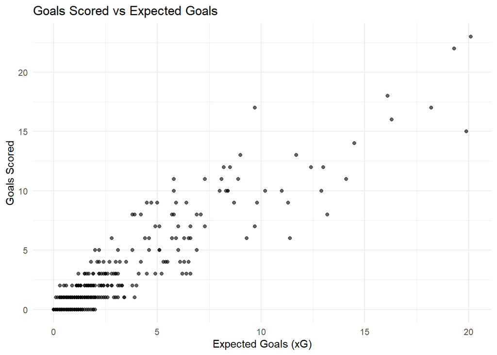

```r
ggplot(df, aes(x = xG_Expected, y = Gls)) +
  geom_point(alpha = 0.6) +
  labs(
    title = "Goals Scored vs Expected Goals",
    x = "Expected Goals (xG)",
    y = "Goals Scored") +
  theme_minimal()
```

This appears to be a pretty linear relationship, higher xG tends to be correlated with higher amount of goals scored. We will now test this correlation coefficient:

```r
print(cor(df$Gls, df$xG_Expected))
```

```
## [1] 0.9316609
```

A coefficient of 0.932 indicates very highly correlated data.